# Predict which Brand of Products Customers Prefer

José Pedro Conceição

March 25, 2019

## Executive summary

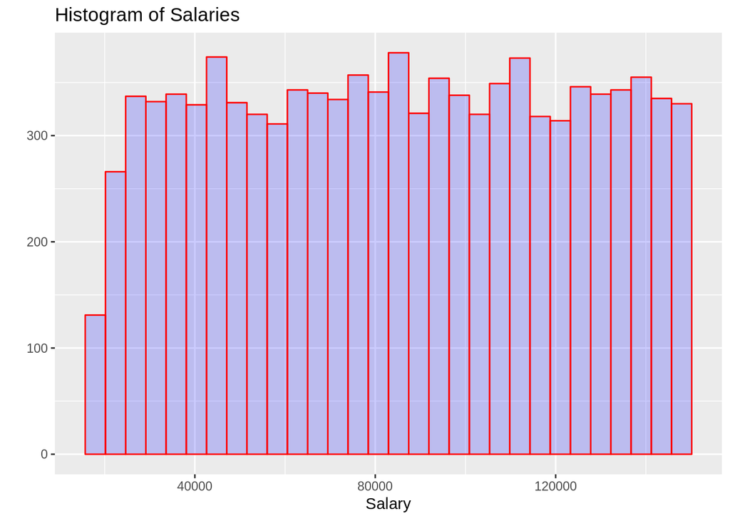

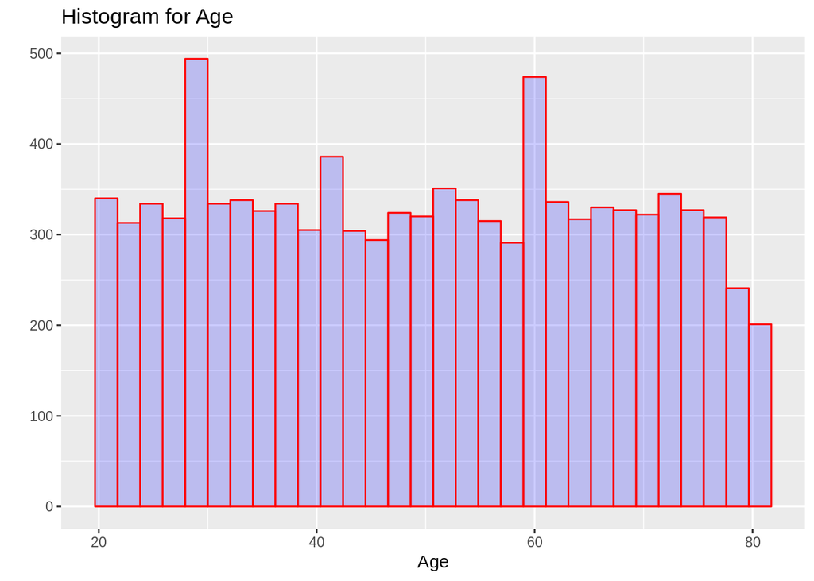

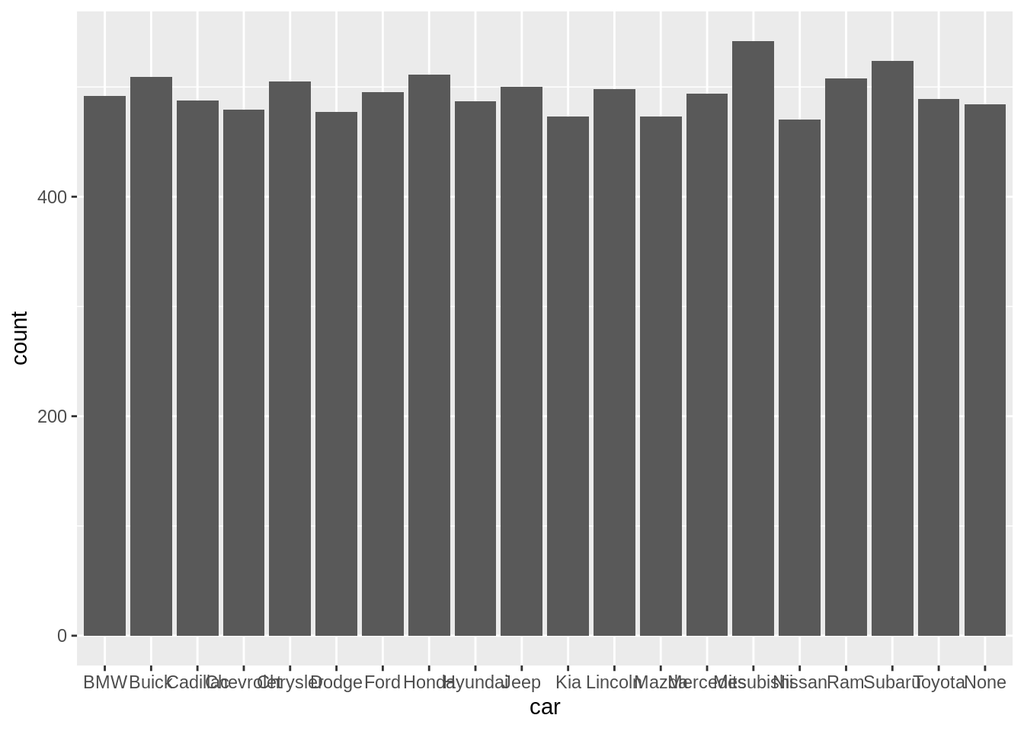

If we want to answer the question that was proposed to us, we need to get data that translates into a real world scenario, it is not possible to add any valueble decision making, since the algorithm will just mimmick the CompleteSurvey Results on to the Incomplete Survey, and give the exact same porpotion of Acer/Sony in percentage. And if summed together the porpotion stays the same.(More detail in the Technical section) Note: I only chose age , salary and age because they are the most important attributes in the context of the problem, it is explained why in the technical section.

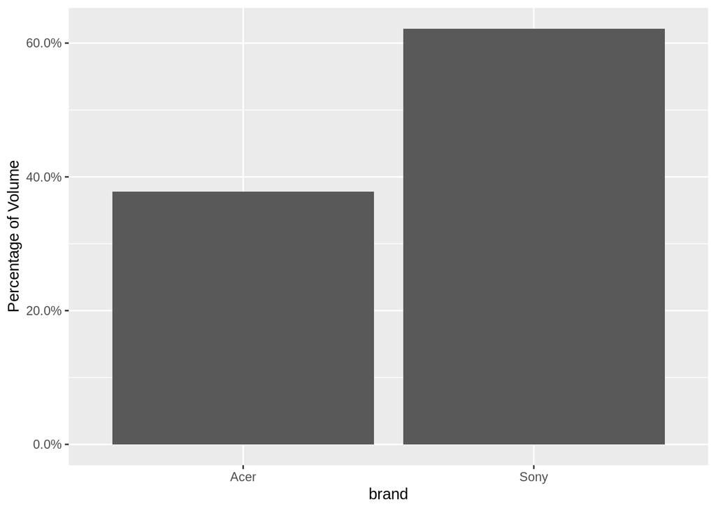

## Technical Section

### Important Variables

By using a C5.0 model we can assess the importance of each variable in percentage with the varImp() function

```r
varImp(TreeComplete)
```

```
## C5.0 variable importance
##
##   only 20 most important variables shown (out of 35)
##
##                           Overall
## salary                     100.00
## age                         96.35
## carRam                      18.28
## carHonda                    16.76
## carLincoln                  16.72
## elevelCollegeDegree         15.98
## carHyundai                  14.72
## carNissan                   14.72
## carChevrolet                 5.87
## carToyota                    0.00
## zipcodeWest South Central    0.00
## carSubaru                    0.00
## zipcodeMid Atlantic          0.00
## carMazda                     0.00
## zipcodeEast North Central    0.00
## zipcodeEast South Central    0.00
## carMercedes                  0.00
## zipcodePacific               0.00
## carBuick                     0.00
## carFord                      0.00
```

### Training and Model Selection

#### Decision Tree C5.0

##### 1st model

I started with a decision tree C5.0, and this is the code for the training indices and traincontrol :

```r
fitControl <- trainControl(method = "repeatedcv", repeats = 10)
inTrain <- createDataPartition(y = CompleteResponsesOG$brand , p = 0.75, list = FALSE )
training <- CompleteResponsesOG[inTrain,]
testing <- CompleteResponsesOG[-inTrain,]
```

Here we begin training our tree, first we use all features to see which of them are important.

```r
#TreeComplete <- train(brand ~.,
  #                    data = training,
  #                    method = "C5.0",
   #                   trcontrol = fitControl,
    #                  tuneLength = 2
      #    )

save(TreeComplete, file = "/home/zordo/Documents/Ubiqum/R/RTask2/Project/Task2/Task2AllOver/CompleTree.rsa")

TreeComplete # shows kappa and acc on training set
```

```
## C5.0
##
## 7424 samples
##    6 predictor
##    2 classes: 'Acer', 'Sony'
##
## No pre-processing
## Resampling: Bootstrapped (25 reps)
## Summary of sample sizes: 7424, 7424, 7424, 7424, 7424, 7424, ...
## Resampling results across tuning parameters:
##
##   model  winnow  trials  Accuracy   Kappa
##   rules  FALSE    1      0.8668992  0.7245328
##   rules  FALSE   10      0.9146252  0.8185162
##   rules   TRUE    1      0.8667506  0.7242427
##   rules   TRUE   10      0.9140808  0.8171690
##   tree   FALSE    1      0.8594591  0.7121511
##   tree   FALSE   10      0.9144398  0.8184523
##   tree    TRUE    1      0.8593260  0.7119161
##   tree    TRUE   10      0.9144817  0.8185364
##
## Accuracy was used to select the optimal model using the largest value.
## The final values used for the model were trials = 10, model = rules
##  and winnow = FALSE.
```

```r
BrandPredictionTree <- predict(TreeComplete, newdata = testing)


postResample(BrandPredictionTree, testing$brand )
```

```
##  Accuracy     Kappa
## 0.9320938 0.8553981
```

Using postResample function we can see our test metrics, and see if our model is overfitting or not, as you can confirm the accuracy and kappa for both training and test sets (CompleteSurvey) are very similar, this translates into a good, non-overfitted model.

After using varImp, I chose Salary Age and Car for my next C5.0 model.

##### Final Model

```r
#TreeASC <- train(brand ~ salary + age + car ,
 #                 data = training,
  #                method = "C5.0",
   #               trcontrol = fitControl,
    #              tuneLenght = 2
     #            )

##save(TreeASC, file = "/home/zordo/Documents/Ubiqum/R/RTask2/Project/Task2/Task2AllOver/TreeASC.rsa")

load(file = "/home/zordo/Documents/Ubiqum/R/RTask2/Project/Task2/Task2AllOver/TreeASC.rsa")

BrandPredictionTreeASC <- predict(TreeASC, newdata = testing)

TreeASC
```

```
## C5.0
##
## 7424 samples
##    3 predictor
##    2 classes: 'Acer', 'Sony'
##
## No pre-processing
## Resampling: Bootstrapped (25 reps)
## Summary of sample sizes: 7424, 7424, 7424, 7424, 7424, 7424, ...
## Resampling results across tuning parameters:
##
##   model  winnow  trials  Accuracy   Kappa
##   rules  FALSE    1      0.8788085  0.7500990
##   rules  FALSE   10      0.9167865  0.8234256
##   rules  FALSE   20      0.9185040  0.8274122
##   rules   TRUE    1      0.8795845  0.7518517
##   rules   TRUE   10      0.9173120  0.8244056
##   rules   TRUE   20      0.9183410  0.8270577
##   tree   FALSE    1      0.8565670  0.7057775
##   tree   FALSE   10      0.9181880  0.8269557
##   tree   FALSE   20      0.9181725  0.8270578
##   tree    TRUE    1      0.8606612  0.7155681
##   tree    TRUE   10      0.9177818  0.8261647
##   tree    TRUE   20      0.9183354  0.8275482
##
## Accuracy was used to select the optimal model using the largest value.
## The final values used for the model were trials = 20, model = rules
##  and winnow = FALSE.
```

```r
confusionMatrix(BrandPredictionTreeASC,testing$brand)
```

```
## Confusion Matrix and Statistics
##
##           Reference
## Prediction Acer Sony
##       Acer  847   77
##       Sony   89 1461
##
##                Accuracy : 0.9329
##                  95% CI : (0.9223, 0.9424)
##     No Information Rate : 0.6217
##     P-Value [Acc > NIR] : <2e-16
##
##                   Kappa : 0.857
##  Mcnemar's Test P-Value : 0.3932
##
##             Sensitivity : 0.9049
##             Specificity : 0.9499
##          Pos Pred Value : 0.9167
##          Neg Pred Value : 0.9426
##              Prevalence : 0.3783
##          Detection Rate : 0.3424
##    Detection Prevalence : 0.3735
##       Balanced Accuracy : 0.9274
##
##        'Positive' Class : Acer
##
```

```r
postResample(BrandPredictionTreeASC, testing$brand )
```

```
##  Accuracy     Kappa
## 0.9329022 0.8569998
```

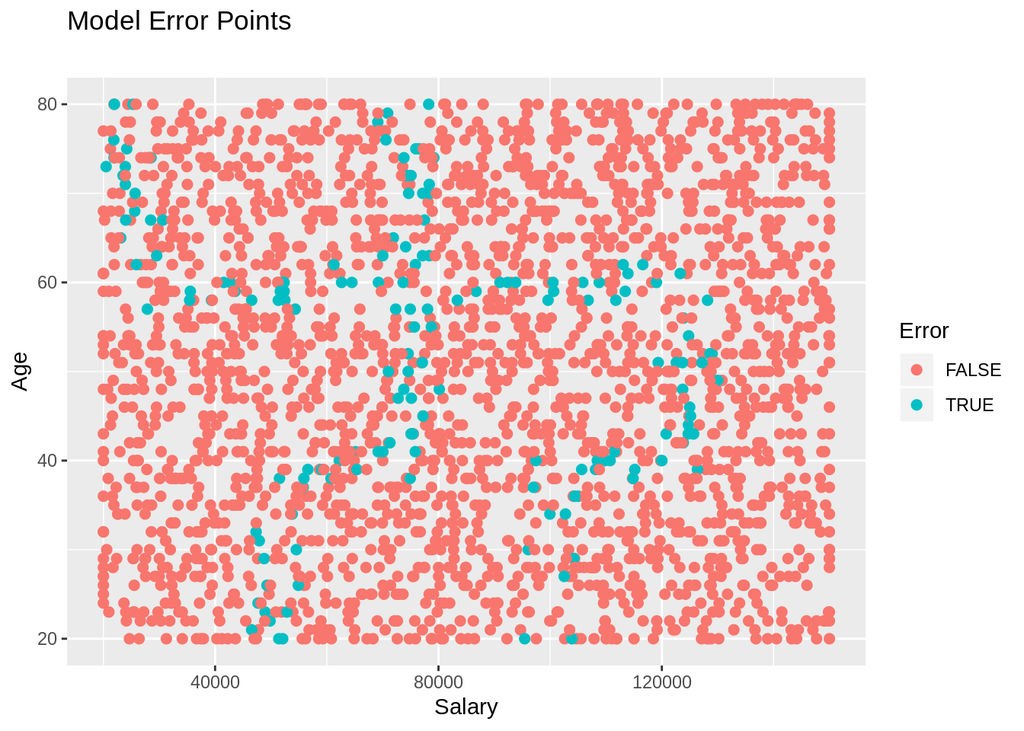

Our results barely improved, but as always it’s faster to process less variables then all of them. In the task it was asked to use a Random Forest, and that is why I am going to use it, however I don’t think that increasing our accuracy and kappa by a few percentage will help with the fundamental issue of this task.

#### Random Forest

##### First Model

Random Forest Algorithm with salary, age and car.

```r
# RandomForestwCar <- train(brand ~ salary + age + car,
#                       data = training,
#                       method="rf",
#                       trcontrol = fitControl,
#                       tunegrid = expand.grid(mtry= c(1,2,3,4,5)) )
#
# save(RandomForestwCar, file = "/home/zordo/Documents/Ubiqum/R/RTask2/Project/Task2/Task2AllOver/RandomForestwCar.rsa")

load(file = "/home/zordo/Documents/Ubiqum/R/RTask2/Project/Task2/Task2AllOver/RandomForestwCar.rsa")
varImp(RandomForestwCar)
```

```
## rf variable importance
##
##   only 20 most important variables shown (out of 21)
##
##                 Overall
## salary        100.00000
## age            64.09461
## carMitsubishi   0.34795
## carMercedes     0.32066
## carChrysler     0.29676
## carSubaru       0.27738
## carHonda        0.27612
## carJeep         0.26670
## carRam          0.24492
## carFord         0.19834
## carBuick        0.19829
## carLincoln      0.18987
## carHyundai      0.16041
## carToyota       0.15733
## carNone         0.14478
## carCadillac     0.13767
## carChevrolet    0.12958
## carDodge        0.09811
## carKia          0.03692
## carNissan       0.01353
```

```r
BrandPredictionRandomForestwCar <- predict(RandomForestwCar, newdata = testing)
RandomForestwCar
```

```
## Random Forest
##
## 7424 samples
##    3 predictor
##    2 classes: 'Acer', 'Sony'
##
## No pre-processing
## Resampling: Bootstrapped (25 reps)
## Summary of sample sizes: 7424, 7424, 7424, 7424, 7424, 7424, ...
## Resampling results across tuning parameters:
##
##   mtry  Accuracy   Kappa
##    2    0.6228653  0.0007243957
##   11    0.9162626  0.8213540692
##   21    0.9103692  0.8087308124
##
## Accuracy was used to select the optimal model using the largest value.
## The final value used for the model was mtry = 11.
```

```r
confusionMatrix(BrandPredictionRandomForestwCar,testing$brand)
```

```
## Confusion Matrix and Statistics
##
##           Reference
## Prediction Acer Sony
##       Acer  910   35
##       Sony   26 1503
##
##                Accuracy : 0.9753
##                  95% CI : (0.9684, 0.9811)
##     No Information Rate : 0.6217
##     P-Value [Acc > NIR] : <2e-16
##
##                   Kappa : 0.9477
##  Mcnemar's Test P-Value : 0.3057
##
##             Sensitivity : 0.9722
##             Specificity : 0.9772
##          Pos Pred Value : 0.9630
##          Neg Pred Value : 0.9830
##              Prevalence : 0.3783
##          Detection Rate : 0.3678
##    Detection Prevalence : 0.3820
##       Balanced Accuracy : 0.9747
##
##        'Positive' Class : Acer
##
```

```r
postResample(BrandPredictionRandomForestwCar,testing$brand)
```

```
##  Accuracy     Kappa
## 0.9753436 0.9476820
```

This are some excellent results on the Test-Set,let’s remove cars, since it is not an important variable and see what happens.

##### Final Model

```r
# RandomForest <- train(brand ~ salary + age  ,
#                             data = training,
#                             method="rf",
#                             trcontrol = fitControl,
#                             tunegrid = expand.grid(mtry=c(1,2,3,4,5)) )
#
#
#
# save(RandomForest, file = "/home/zordo/Documents/Ubiqum/R/RTask2/Project/Task2/Task2AllOver/RandomForest.rsa")
load(file = "/home/zordo/Documents/Ubiqum/R/RTask2/Project/Task2/Task2AllOver/RandomForest.rsa")
varImp(RandomForest)
```

```
## rf variable importance
##
##        Overall
## salary     100
## age          0
```

```r
BrandPredictionRF <- predict(RandomForest, newdata = testing)

RandomForest
```

```
## Random Forest
##
## 7424 samples
##    2 predictor
##    2 classes: 'Acer', 'Sony'
##
## No pre-processing
## Resampling: Bootstrapped (25 reps)
## Summary of sample sizes: 7424, 7424, 7424, 7424, 7424, 7424, ...
## Resampling results:
##
##   Accuracy   Kappa
##   0.9038002  0.7952569
##
## Tuning parameter 'mtry' was held constant at a value of 2
```

```r
confusionMatrix(data = BrandPredictionRF, testing$brand)
```

```
## Confusion Matrix and Statistics
##
##           Reference
## Prediction Acer Sony
##       Acer  919   35
##       Sony   17 1503
##
##                Accuracy : 0.979
##                  95% CI : (0.9725, 0.9843)
##     No Information Rate : 0.6217
##     P-Value [Acc > NIR] : <2e-16
##
##                   Kappa : 0.9555
##  Mcnemar's Test P-Value : 0.0184
##
##             Sensitivity : 0.9818
##             Specificity : 0.9772
##          Pos Pred Value : 0.9633
##          Neg Pred Value : 0.9888
##              Prevalence : 0.3783
##          Detection Rate : 0.3715
##    Detection Prevalence : 0.3856
##       Balanced Accuracy : 0.9795
##
##        'Positive' Class : Acer
##
```

```r
postResample(BrandPredictionRF,testing$brand)
```

```
##  Accuracy     Kappa
## 0.9789814 0.9554847
```

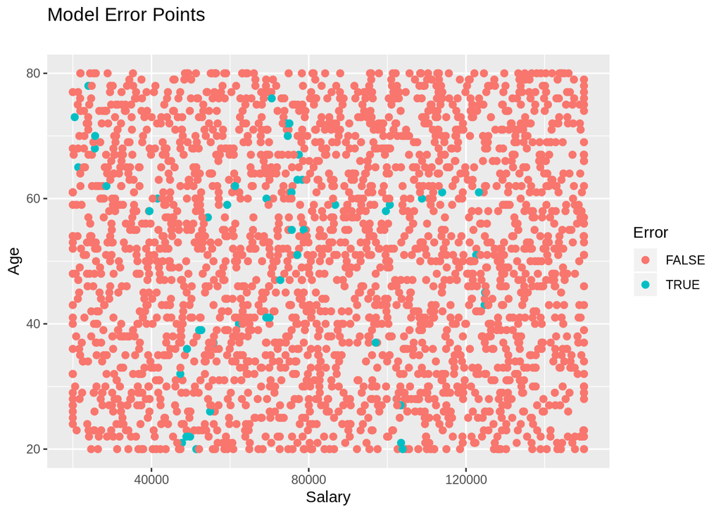

Alot less errors ! But the border can still be seen clearly ! Let’s try with another algorithm

#### K-NN

Unlike other models, K-NN requires a little of detailed atention. Why ? Because the way the model fundamentally works, having different scaling features will cause issues, and this is why we need to normalize the data.

```r
normalize2 <- preProcess(CompleteResponsesOG[,], method=c("range"))
normalize2
```

```
## Created from 9898 samples and 7 variables
##
## Pre-processing:
##   - ignored (4)
##   - re-scaling to [0, 1] (3)
```

```r
Complete_norm <- predict(normalize2, CompleteResponsesOG)
set.seed(28)
inTraining_norm<-createDataPartition(Complete_norm$brand, p=.75, list = FALSE)
training_norm<-Complete_norm[inTraining_norm,]
testing_norm<-Complete_norm[-inTraining_norm,]



knnFitAS <- train(brand ~ age + salary, training_norm, method = "knn", trControl=fitControl)

save(knnFitAS, file = "/home/zordo/Documents/Ubiqum/R/RTask2/Project/Task2/Task2AllOver/knnfit.rsa")

load(file="/home/zordo/Documents/Ubiqum/R/RTask2/Project/Task2/Task2AllOver/knnfit.rsa")

varImp(knnFitAS)
```

```
## ROC curve variable importance
##
##        Importance
## salary        100
## age             0
```

```r
BrandPredictionKNN <- predict(knnFitAS, newdata = testing_norm )

knnFitAS
```

```
## k-Nearest Neighbors
##
## 7424 samples
##    2 predictor
##    2 classes: 'Acer', 'Sony'
##
## No pre-processing
## Resampling: Cross-Validated (10 fold, repeated 10 times)
## Summary of sample sizes: 6682, 6681, 6682, 6681, 6682, 6682, ...
## Resampling results across tuning parameters:
##
##   k  Accuracy   Kappa
##   5  0.9162183  0.8220641
##   7  0.9194386  0.8289445
##   9  0.9197340  0.8296936
##
## Accuracy was used to select the optimal model using the largest value.
## The final value used for the model was k = 9.
```

```r
confusionMatrix(data = BrandPredictionKNN, testing_norm$brand)
```

```
## Confusion Matrix and Statistics
##
##           Reference
## Prediction Acer Sony
##       Acer  843  117
##       Sony   93 1421
##
##                Accuracy : 0.9151
##                  95% CI : (0.9034, 0.9258)
##     No Information Rate : 0.6217
##     P-Value [Acc > NIR] : <2e-16
##
##                   Kappa : 0.8205
##  Mcnemar's Test P-Value : 0.1125
##
##             Sensitivity : 0.9006
##             Specificity : 0.9239
##          Pos Pred Value : 0.8781
##          Neg Pred Value : 0.9386
##              Prevalence : 0.3783
##          Detection Rate : 0.3407
##    Detection Prevalence : 0.3880
##       Balanced Accuracy : 0.9123
##
##        'Positive' Class : Acer
##
```

```r
postResample(BrandPredictionKNN,testing_norm$brand)
```

```
##  Accuracy     Kappa
## 0.9151172 0.8204510
```

Let’s plot the error like we did for the other models and see what happens !

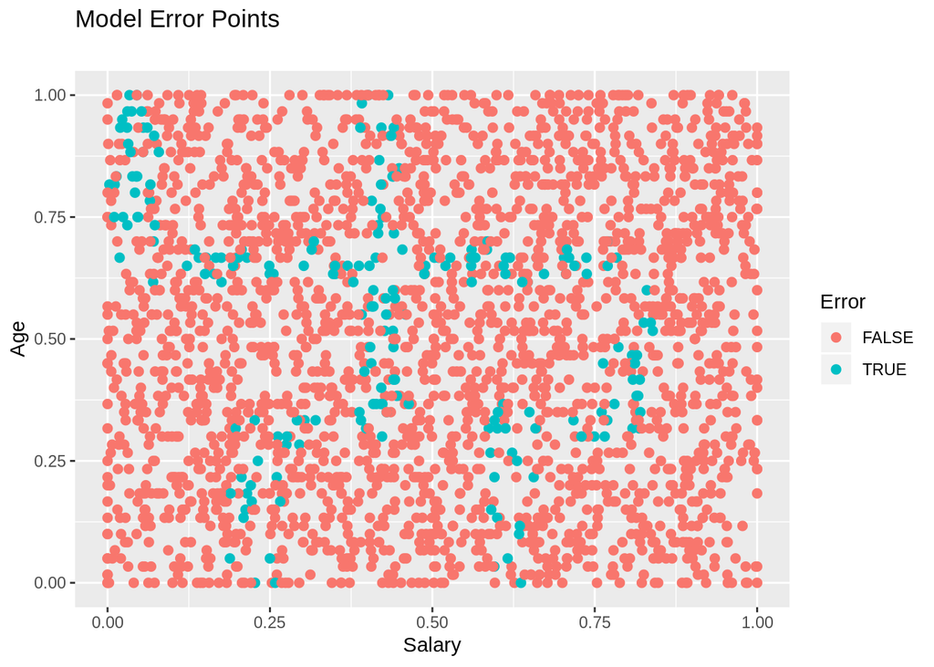

### Incomplete-Survey

```r
IncompleteSurvery <- read.csv(file ="/home/zordo/Downloads/SurveyIncomplete.csv",header = TRUE , sep = ",")
```

Since we already saved the models we don’t need to rewrite them.

```r
predictionTreeALLincResp <- predict(RandomForest , newdata = IncompleteSurvery)


IncompleteSurvery[8] <- NULL ## to delete the full 0's column on the IncompleteSurveys dataframe

IncompleteSurvery <- cbind(IncompleteSurvery, predictionTreeALLincResp)
#bind the new predictions on the Survey.
```

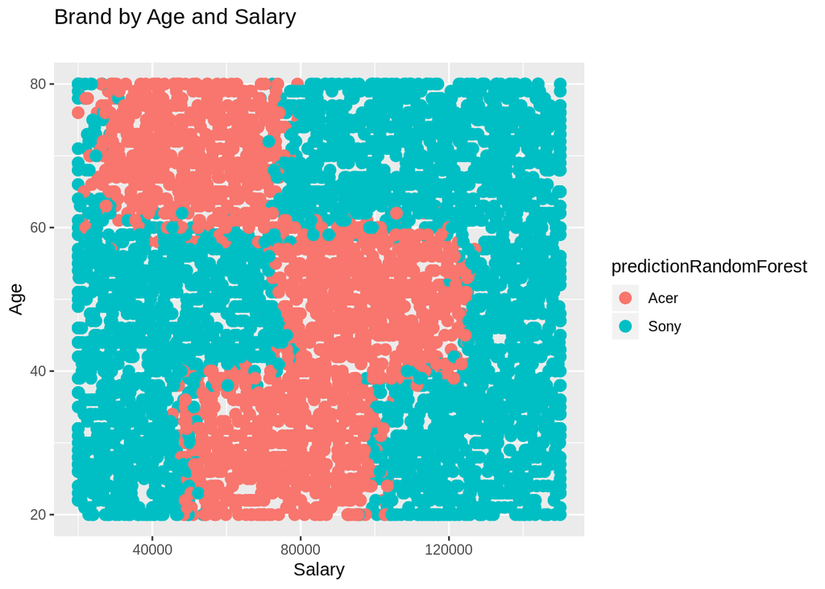

### Why does this happen ?

This happens because our data is not normally distributed, it’s homogeneous distributed, which for our particular problem translates into an impossible task. We can prove that by ploting a some qqplots:

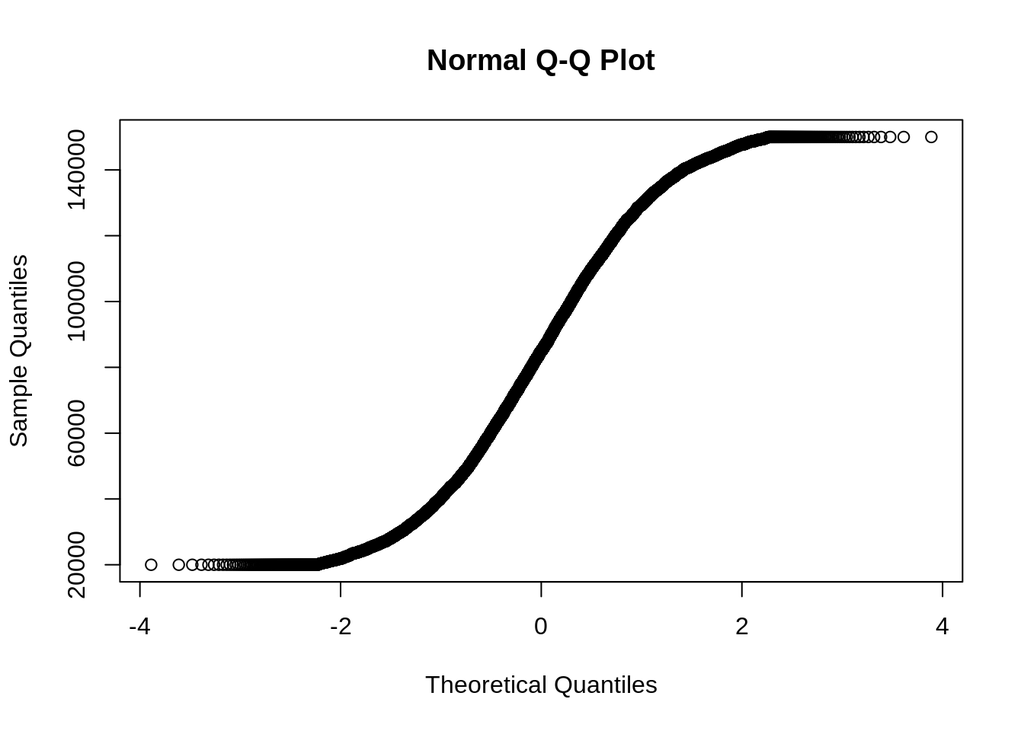

```r
qqnorm(CompleteResponsesOG$salary)
```

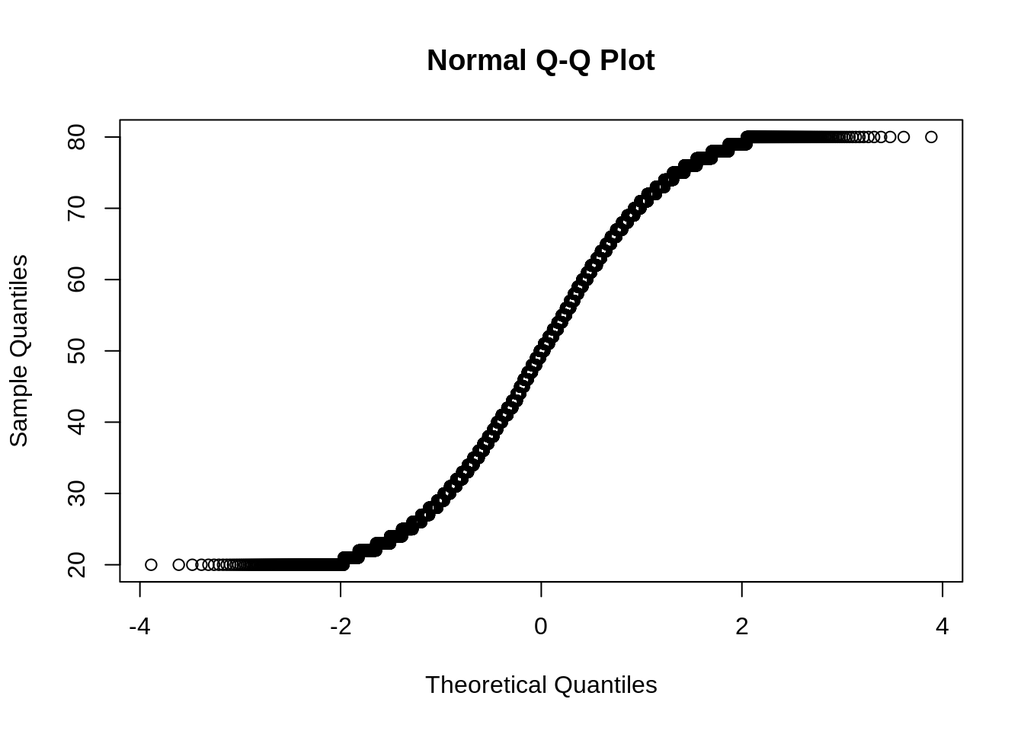

```r
qqnorm(CompleteResponsesOG$age)
```

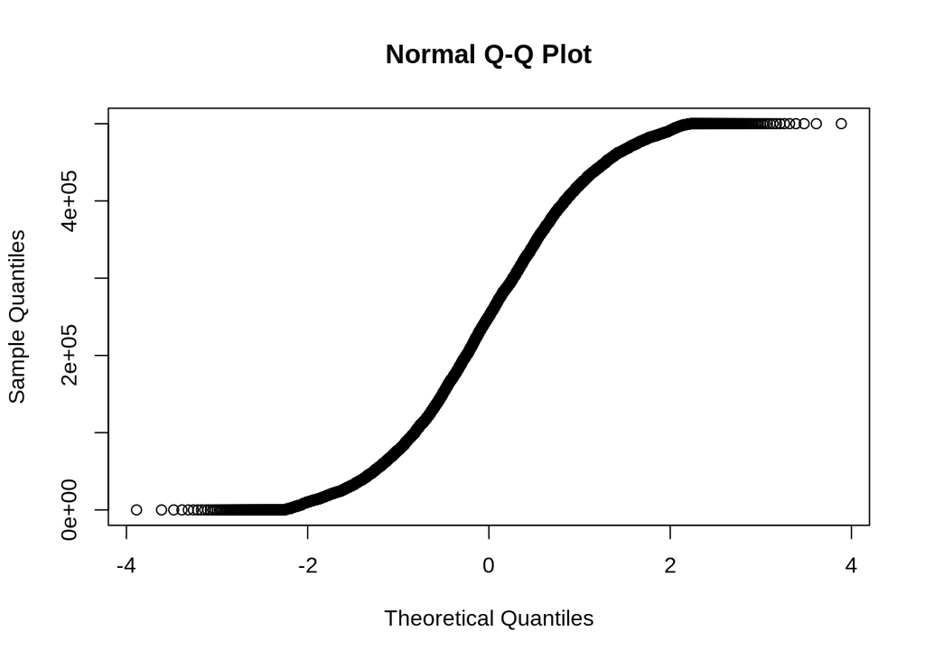

```r
qqnorm(CompleteResponsesOG$credit)
```

This simple image explains how different data distributions have effect on the qqplot.

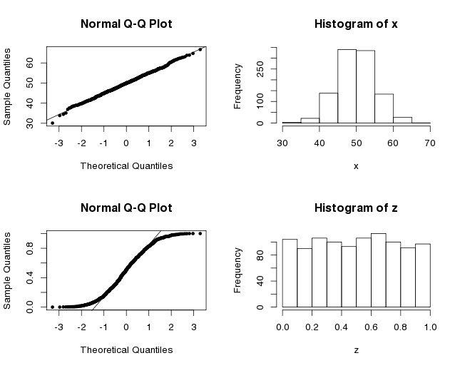

If we wanted to decide which company brand to pursue we would need a normal distribution to have valued results on the Incomplete Survey !  
For the Incomplete Survey:

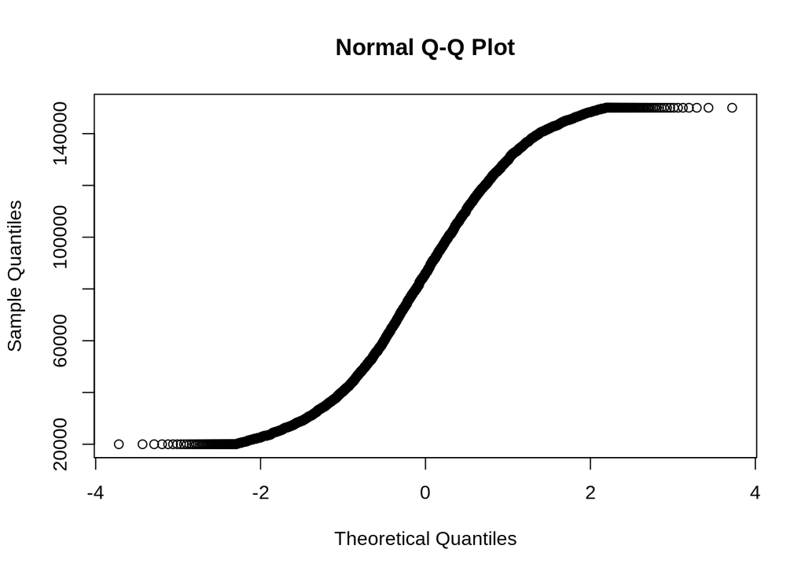

```r
qqnorm(IncompleteSurvery$salary)
```

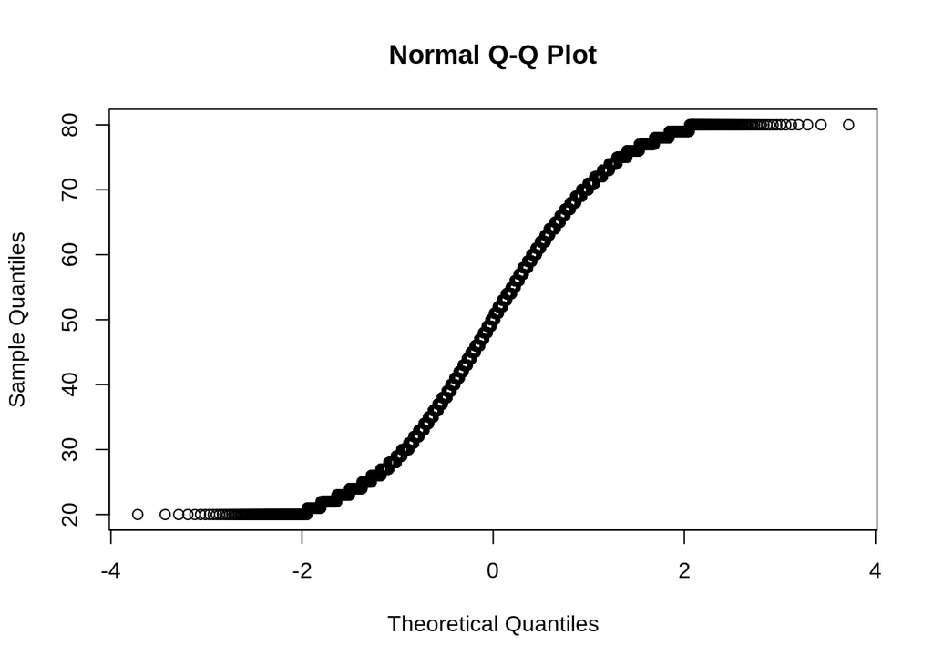

```r
qqnorm(IncompleteSurvery$age)
```

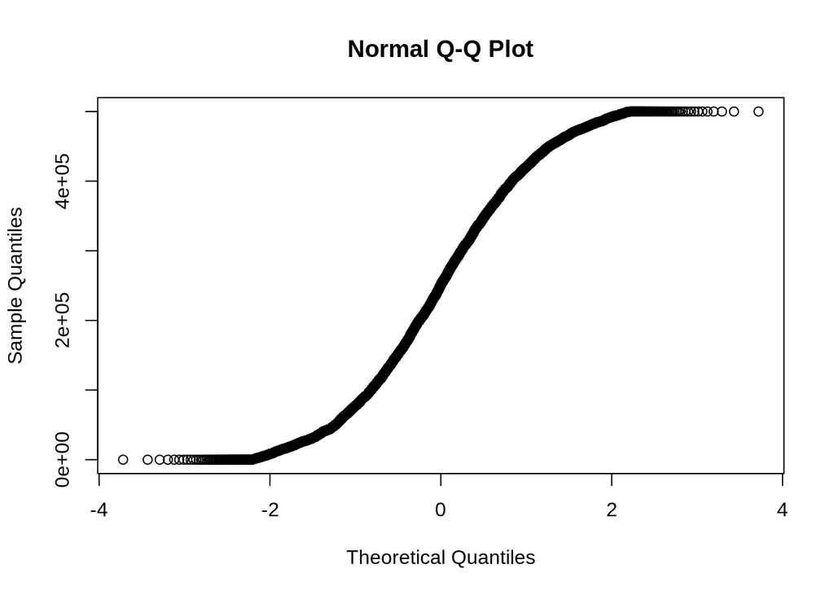

```r
qqnorm(IncompleteSurvery$credit)
```

## Conclusion

So if we want to make customer profiles we want data that is homogeneous distributed, and if we want to make predictions we want it as “real” distributed as possible

## Extras

On this section I included some functions I created in R that facilitates creating sets, training models and predicting.

```r
#### Pre-processing function ####




pProcessing <- function(data)
{




  data$brand <- factor(data$brand,
                                      levels = c(0 ,1 ) ,
                                      label = c("Acer","Sony"))

  data$elevel <- factor(data$elevel,
                                       levels = c(0,1,2,3,4),
                                       labels = c("No high school", "High School", "Some College", "College Degree", "Masters PHD"))
  #CarBrand
  data$car <- factor(data$car,
                                    levels = c(1,2,3,4,5,6,7,8,9,10,11,12,13,14,15,16,17,18,19,20),
                                    labels = c("BMW","Buick", "Cadillac", "Chevrolet","Chrysler","Dodge","Ford","Honda","Hyundai","Jeep","Kia","Lincoln","Mazda","Mercedes","Mitsubishi","Nissan","Ram","Subaru","Toyota","None"))
  #Region
  data$zipcode <- factor(data$zipcode,
                                        levels = c(0,1,2,3,4,5,6,7,8),
                                        labels = c("New England","Mid Atlantic","East North Central","West North Central","South Atlantic","East South Central","West South Central","Mountain","Pacific"))




}



#### Training/Testing Set Function ####

TrainAndTestSets <- function(label,p,data){

    inTrain <- createDataPartition(y= label, p = p , list = FALSE)
                                training <- data[inTrain]
                                testing <- data[-inTrain]

                  list(trainingSet=training ,testingSet=testing )


}

#### Training Model Functions ####

TrainModel <- function(formula,data,method,tunelength = 0,tunegrid = 0)
{
  fitControl <- trainControl(method = "repeatedcv", repeats = 10)
  if (method == "rf")
  {
    model <- train(formula ,
                   data = data ,
                   method = method ,
                   trcontrol =fitControl,
                   tunegrid = tunegrid  )
  }
     else
    {
      model <-train(formula ,
                    data = data ,
                    method = method,
                    trcontrol= fitControl,
                    tunelength = tunelength)
    }

  model
  }



#### Predicting Function and postResample ####


PredictionsFunction <- function(model,newdata,label)
{
  Brandpredictions <- predict(model,newdata =newdata)


  Brandpredictions
}
```